# PDX: Drug trails

GDC (Susana)

Alistair Martin

Last modified: 03 Jan 2018

# Load libraries, functions and data

```
Bioconductor version 3.6 (BiocInstaller 1.28.0), ?biocLite for help
```

```
Read 61.8% of 113262 rows
Read 113262 rows and 749 (of 749) columns from 0.176 GB file in 00:00:04
```

# QC

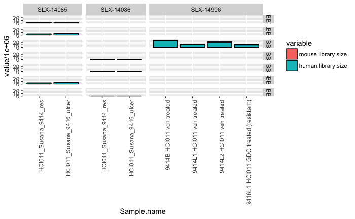

[figure not shown]

```r
read.depth.plots(rnaseq$meta)
```

We appear to have some very small libraries. Given how few samples we have, let’s generate a table with read counts.

```r
rnaseq$meta[order(human.library.size),.(Sample.name,Pool,human.library.size)]
```

| Sample.name | Pool | human.library.size |
| --- | --- | --- |
| HCI011_Susana_9416_ulcer | SLX-14086 | 11276 |
| HCI011_Susana_9416_ulcer | SLX-14086 | 11945 |
| HCI011_Susana_9416_ulcer | SLX-14086 | 12303 |
| HCI011_Susana_9414_res | SLX-14086 | 14488 |
| HCI011_Susana_9414_res | SLX-14086 | 15543 |
| HCI011_Susana_9414_res | SLX-14086 | 15784 |
| HCI011_Susana_9414_res | SLX-14085 | 2071246 |
| HCI011_Susana_9416_ulcer | SLX-14085 | 2877658 |
| HCI011_Susana_9414_res | SLX-14085 | 3631424 |
| HCI011_Susana_9414_res | SLX-14085 | 3677920 |

[output cut: 6 more lines]

However, note that the samples in SLX-14086, the “failed” libraries, are the same as those in SLX-14085. Given this, the trail arms are fully present and we can perform the analysis. First, let us merge the lanes.

```r
#rnaseq <- subset.PDX(rnaseq, rnaseq$meta[,human.library.size>1E6])
rnaseq <- merge.PDX(rnaseq)
rnaseq$meta <- merge(rnaseq$meta,meta,sort=F)
rnaseq$meta[,merged.lanes:=factor(as.numeric(as.factor(merged.lanes)))]
```

Let’s just double check the trail arms.

```r
table(rnaseq$meta[,Treatment])
```

```
control     GDC
      3       3
```

# PCAs

```r
pca <- pca.run(rnaseq$human)
summary(pca)
```

```
Importance of components:
                          PC1     PC2     PC3     PC4     PC5       PC6
Standard deviation     19.261 15.2350 13.5724 11.8774 8.46420 1.102e-14
Proportion of Variance  0.371  0.2321  0.1842  0.1411 0.07164 0.000e+00
Cumulative Proportion   0.371  0.6031  0.7873  0.9284 1.00000 1.000e+00
```

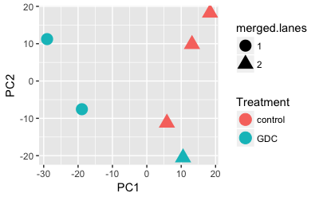

```r
pca <- cbind(rnaseq$meta,pca$x)
ggplot(pca) + aes(x=PC1,y=PC2,col=Treatment,shape=merged.lanes) + geom_point(size=5)
```

We appear to have a batch effect associated with the sequencing that we need to include in the statistical models. How does the pca change if we try accounting for it?

```r
y <- pca.prep(rnaseq$human)
y <- removeBatchEffect(y,design = model.matrix(~rnaseq$meta$Treatment), batch= rnaseq$meta$merged.lanes)
pca <- prcomp(t(y),scale=T)
summary(pca)
```

```
Importance of components:
                           PC1     PC2     PC3     PC4       PC5       PC6
Standard deviation     19.8441 16.7624 14.5966 10.5912 1.918e-14 9.221e-15
Proportion of Variance  0.3938  0.2810  0.2131  0.1122 0.000e+00 0.000e+00
Cumulative Proportion   0.3938  0.6748  0.8878  1.0000 1.000e+00 1.000e+00
```

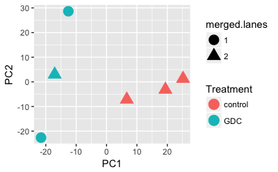

```r
pca <- cbind(rnaseq$meta,pca$x)
ggplot(pca) + aes(x=PC1,y=PC2,col=Treatment,shape=merged.lanes) + geom_point(size=5)
```

That seems to work well. :-)

# Model: ~ Treatment + Flowcell

```r
sequencing <- rnaseq$meta[,merged.lanes]
treatment <- rnaseq$meta[,factor(Treatment,levels = c("control","GDC"))]
d <- model.matrix(~ 0 + treatment + sequencing)
d
```

```
  treatmentcontrol treatmentGDC sequencing2
1                0            1           0
2                0            1           0
3                1            0           1
4                1            0           1
5                1            0           1
6                0            1           1
attr(,"assign")
[1] 1 1 2
attr(,"contrasts")
attr(,"contrasts")$treatment
[1] "contr.treatment"

attr(,"contrasts")$sequencing
[1] "contr.treatment"
```

```r
cont.matrix <- matrix(c(-1,1,rep(0,dim(d)[2]-2)), dim(d)[2], 1)
colnames(cont.matrix) <- c("GDP.minus.control")
rownames(cont.matrix) <- colnames(d)
cont.matrix
```

```
                 GDP.minus.control
treatmentcontrol                -1
treatmentGDC                     1
sequencing2                      0
```

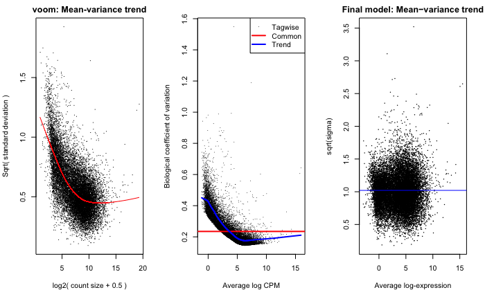

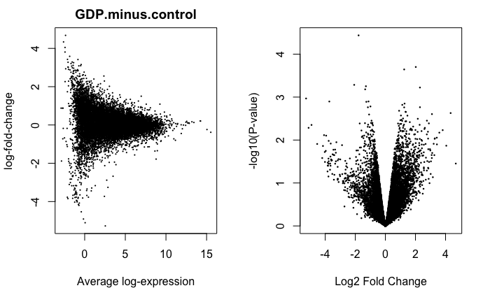

```r
#Perform DE
DE.data <- DE.run(rnaseq$human,d,2,cont.matrix = cont.matrix)
```

```r
#Top DE genes table
DE <- topTable.annotated.DE(DE.data$efit)
```

```
No DE genes
```

```r
if(nrow(DE)!=0){
  table(DE[,direction])
  DE[direction=="up.reg",.(direction,ENSEMBL,SYMBOL,adj.P.Val,logFC)]
  DE[direction=="down.reg",.(direction,ENSEMBL,SYMBOL,adj.P.Val,logFC)]
#Pheatmap w/ batch correction
  i <- match(DE$ENSEMBL,rownames(DE.data$v$E))
  y <- removeBatchEffect(DE.data$v$E[i,],design = model.matrix(~drug), batch= pdx)
  labels.col <- rep("",nrow(rnaseq$meta))
  labels.row <- DE$SYMBOL
  ann.col <- as.data.frame(rnaseq$meta[,.(pdx,drug)])
  rownames(ann.col) <- rnaseq$meta[,Sample.name]
  pheatmap(y,labels_col=labels.col,labels_row=labels.row,annotation_col = ann.col,scale="row")
}
#GSEA - c6
gsea <- GSEA.run(DE.data$v,d,cont.matrix[,1],Hs.c6,0.05)
gsea[Direction=="Up",.(rn,NGenes,Direction,FDR)]
```

| rn | NGenes | Direction | FDR |
| --- | --- | --- | --- |

```r
gsea[Direction=="Down",.(rn,NGenes,Direction,FDR)]
```

| rn | NGenes | Direction | FDR |
| --- | --- | --- | --- |

```
The argument 'rnaseq' is deprecated and will be removed in the next release of GSVA. Please use the 'kcdf' argument instead.
```

```
Estimating GSVA scores for 4432 gene sets.
Computing observed enrichment scores
Estimating ECDFs in microarray data with Gaussian kernels
Using parallel with 4 cores
```

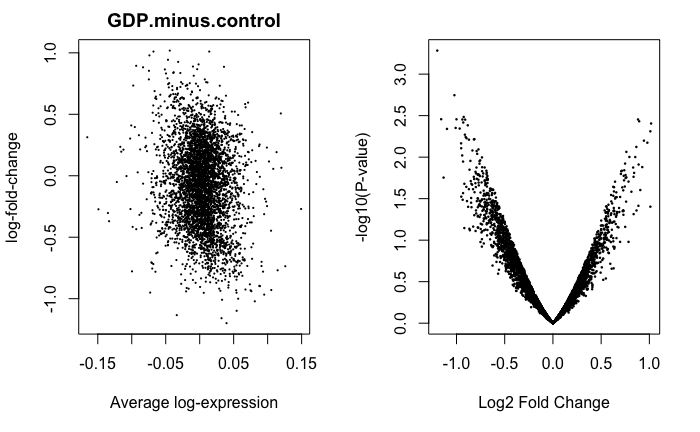

```r
# ssGSEA
ssGSEA.data <- ssGSEA.run(DE.data$v$E,Hs.c2,d,cont.matrix=cont.matrix)
```

```r
#Top DE gene.sets table
ssGSEA <- topTable.annotated.ssGSEA(ssGSEA.data$efit)
```

```
No DE genes
```

```r
if(nrow(ssGSEA)!=0){
  ssGSEA[direction=="up.reg",.(direction,gene.set,adj.P.Val,logFC)]
  ssGSEA[direction=="down.reg",.(direction,gene.set,adj.P.Val,logFC)]

  #Pheatmap w/ batch correction
  i <- match(ssGSEA$gene.set,rownames(ssGSEA.data$w))
  y <- removeBatchEffect(ssGSEA.data$w[i,],design = model.matrix(~drug), batch=pdx)
  labels.col <- rep("",nrow(rnaseq$meta))
  labels.row <- ssGSEA$gene.set
  ann.col <- as.data.frame(rnaseq$meta[,.(pdx,drug)])
  rownames(ann.col) <- rnaseq$meta[,Sample.name]
  pheatmap(y,labels_col=labels.col,labels_row=labels.row,annotation_col = ann.col,scale="row")
}
```

Sadly, we do not see have anything reported as DE. This is most likely due to the batch effect generated by the sequencing being performed across two different flowcells. With this compounding factor, we will always struggle to obtain anything relevant from a standard differential expression analysis of six samples. My personal suggestion would be to repool and resequecing everything together so as to remove this.

## Specific genes

The below plots show the normalised expression for the genes of interest across the two conditions. We have shifted the expressions in an attempt to account for the batch effect.

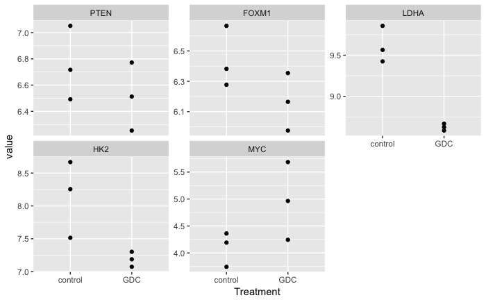

```r
genes <- c("PTEN","FOXM1","LDHA","HK2","MYC")
genes.ensembl <- mapIds(org.Hs.eg.db,keys=genes,column = "ENSEMBL",keytype = "SYMBOL")
i <- match(genes.ensembl,rownames(DE.data$v$E))
x <- t(removeBatchEffect(DE.data$v$E[i,],design = model.matrix(~treatment), batch=sequencing))
colnames(x) <- genes
x <- cbind(rnaseq$meta[,.(Treatment,merged.lanes)],x)
x <- melt(x,id.vars = c("Treatment","merged.lanes"))
ggplot(x) + aes(x=Treatment,y=value) + geom_point() + facet_wrap(~variable,scales = "free_y")
```

## Specific pathways

The below plots show the normalised expression for the pathways of interest across the two conditions. We have shifted the expressions in an attempt to account for the batch effect.

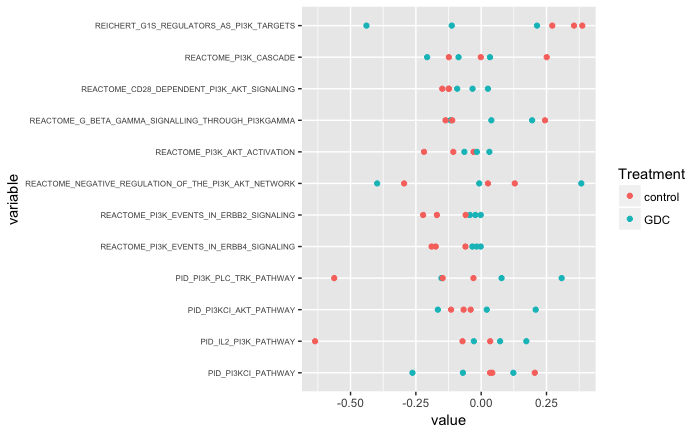